Skip to main content

# Від чого залежить ціна діаманта: регресійне моделювання

Лабораторна робота №3. Основи регресійного моделювання

Автор

Демчук Владислав

Дата

26 листопада 2026 р.

**Пакети й налаштування**

```python
import os
import json
import hashlib
import warnings

import numpy as np
import pandas as pd
import matplotlib.pyplot as plt
import seaborn as sns
from scipy import stats
import statsmodels.formula.api as smf
from statsmodels.stats.diagnostic import het_breuschpagan
from statsmodels.stats.outliers_influence import OLSInfluence
from sklearn.model_selection import train_test_split, KFold
from sklearn.ensemble import HistGradientBoostingRegressor
from sklearn.metrics import mean_absolute_error, root_mean_squared_error, r2_score

warnings.filterwarnings("ignore")
sns.set_theme(style="whitegrid")
os.makedirs("figures", exist_ok=True)
os.makedirs("results", exist_ok=True)

numbers = {}


def usd(x):
    return f"{x:,.0f}".replace(",", " ") + " $"
```

# 1 Вступ

## 1.1 Предметна область, ціль і питання

Ціна діаманта на роздрібному ринку визначається так званими «4C»: вагою (*carat*), огранкою (*cut*), кольором (*color*) і чистотою (*clarity*). Продовжую лабораторну №2 на тому самому наборі **Diamonds**.

- **Одиниця спостереження** — один огранений круглий діамант з каталогу онлайн-продавця.
- **Ціль** — `price`, ціна в доларах США (ціни 2008 року), числова й неперервна.
- **Дослідницьке питання.** Наскільки точно чотири характеристики з сертифіката (4C) прогнозують ціну *нового* діаманта з того самого ринку і як ціна пов’язана з вагою, якщо огранка, колір і чистота однакові?
- **Для яких спостережень потрібен прогноз.** Для круглих діамантів того самого типу й періоду, у межах діапазону даних (0.2–5 ct, ціна до 18 823 $). Наприклад, покупець чи продавець хоче оцінити, чи справедлива ціна каменя з відомими 4C.

## 1.2 Що підказує література

1. **Chu (2001)** будує модель ціни діамантів за 4C на даних сінгапурських оголошень. Ціна зростає з вагою швидше, ніж пропорційно, а якісні характеристики працюють як надбавки до ціни. Звідси **вибір змінних** (4C як основні предиктори) і **форма моделі**: логарифм ціни дає мультиплікативні (відсоткові) ефекти колір/чистота і рівномірніший розкид залишків.
2. **Scott і Yelowitz (2010)** на даних трьох великих онлайн-продавців показали **стрибки ціни на «круглих» вагах**: камінь 0.5 ct дорожчий за 0.49 ct на 18 % і більше, а 1 ct дорожчий за трохи легший на 5–10 %. Це підказує **межі інтерпретації**: зв’язок ціни з вагою не гладкий, тому проста степенева модель систематично помилятиметься біля порогів 0.5, 1, 1.5, 2 ct. Звідси моя модифікація регресії (порогові змінні і сплайн).
3. **Wickham і Grolemund (2017)** на цьому самому наборі показують, що в шкалі log–log зв’язок ціни з вагою майже лінійний і що «гірша» якість здається дорожчою через змішування з вагою. Це методологічна підстава завжди оцінювати ефекти якості **за сталої ваги**.

## 1.3 Гіпотези (записані до оцінювання моделей)

- **H1 (вага, з EDA і літератури).** За однакових огранки, кольору й чистоти ціна зростає з вагою **швидше, ніж пропорційно**: еластичність ціни за вагою $\beta_{\log carat} > 1$. *Перевірка:* знак, величина й 95 % довірчий інтервал коефіцієнта при $\log(carat)$ у заздалегідь описаній моделі M2 (нижче), стійкі до гетероскедастичності стандартні похибки HC3.
- **H2 (чистота, з EDA і літератури).** За однакової ваги, огранки й кольору ціна **монотонно зростає** з чистотою від I1 до IF, і надбавка IF порівняно з I1 перевищує 100 %. *Перевірка:* коефіцієнти рівнів `clarity` у M2: знаки, порядок і 95 % ДІ надбавки $e^{\beta}-1$.

**Увага**

Обидві гіпотези **виникли з EDA** лабораторної №2 (нахил 1.68 у log–log; чистота найсильніше пов’язана з ціною каменів 1 ct), яке охоплювало **весь** набір. Тому їх перевірка на тих самих даних є **розвідувальною**, а не підтверджувальною.

# 2 Методи

## 2.1 Дані

**Код**

```python
raw_path = "data/raw/diamonds.csv"
url = "https://raw.githubusercontent.com/tidyverse/ggplot2/main/data-raw/diamonds.csv"

if not os.path.exists(raw_path):
    os.makedirs("data/raw", exist_ok=True)
    pd.read_csv(url).to_csv(raw_path, index=False)

with open(raw_path, "rb") as f:
    sha = hashlib.sha256(f.read()).hexdigest()

raw = pd.read_csv(raw_path)

df = raw.drop_duplicates()
df = df[(df["x"] > 0) & (df["y"] > 0) & (df["z"] > 0)]
df["depth_check"] = df["z"] / ((df["x"] + df["y"]) / 2) * 100
df = df[abs(df["depth_check"] - df["depth"]) <= 5]
df = df.drop(columns="depth_check")
df = df.reset_index(drop=True)

df["cut"] = pd.Categorical(df["cut"], categories=["Fair", "Good", "Very Good", "Premium", "Ideal"], ordered=True)
df["color"] = pd.Categorical(df["color"], categories=["J", "I", "H", "G", "F", "E", "D"], ordered=True)
df["clarity"] = pd.Categorical(df["clarity"], categories=["I1", "SI2", "SI1", "VS2", "VS1", "VVS2", "VVS1", "IF"], ordered=True)

df["cut_code"] = df["cut"].cat.codes
df["color_code"] = df["color"].cat.codes
df["clarity_code"] = df["clarity"].cat.codes

df["log_price"] = np.log(df["price"])
df["log_carat"] = np.log(df["carat"])

numbers["n_raw"] = len(raw)
numbers["n_clean"] = len(df)
numbers["sha"] = sha

print("Рядків у файлі:", len(raw))
print("Рядків після очищення:", len(df))
print("SHA-256 файлу:", sha)
```

```
Рядків у файлі: 53940
Рядків після очищення: 53748
SHA-256 файлу: 9574730b03aba241d899c4a97511c5061b19358fab89510774fb6c24168345c4
```

- **Джерело:** набір `diamonds` з пакета ggplot2 (Wickham 2016), файл `data-raw/diamonds.csv` з репозиторію tidyverse/ggplot2 (гілка `main`), отримано **в листопаді 2026**. Контрольна сума SHA-256 файлу 9574730b03aba241… записана в звіті, тож ту саму версію можна перевірити.
- **Умови використання:** ліцензія MIT пакета ggplot2; дані відкриті.
- **Розмір:** 53 940 рядків і 10 змінних; після очищення 53 748 (вилучено повні дублікати, камені з нульовими розмірами і рядки, де `depth` суперечить розмірам x, y, z).
- **Обмеження даних:** спостережні дані одного ринку 2008 року; **немає дати й продавця**; ціни обрізані зверху (максимум 18 823 $); у наборі тільки круглі камені. Модель не можна переносити на інші роки, форми чи синтетичні діаманти.

## 2.2 Поділ і захист від витоку

Спостереження незалежні (один рядок — окремий камінь, повторних вимірювань і часу немає), тому **випадковий поділ 80/20 з `seed = 42`**. Поділ я зафіксував **до** підбору моделей; тестову частину не використовую аж до фінальної оцінки.

**Код**

```python
train, test = train_test_split(df, test_size=0.2, random_state=42)

print("Навчальна частина:", len(train), "рядків, середня ціна", round(train["price"].mean()), "$")
print("Тестова частина:", len(test), "рядків, середня ціна", round(test["price"].mean()), "$")
```

```
Навчальна частина: 42998 рядків, середня ціна 3938 $
Тестова частина: 10750 рядків, середня ціна 3900 $
```

- Усі графіки розділу 2.3 і всю діагностику я побудував **тільки на навчальній частині**.
- **Обмеження незалежності тесту.** Лабораторна №2 бачила весь набір, зокрема майбутню тестову частину. Вона вже підказала рішення: логарифмувати ціну й вагу, відкинути x, y, z (дублюють вагу), не брати `depth` і `table` (слабкий зв’язок), а також гіпотези H1–H2. Тому тестова оцінка трохи оптимістична. Нових даних з того самого ринку немає, отже повністю незалежної перевірки зробити не можу.
- **Доступність предикторів.** 4C вказані в сертифікаті до продажу, тож вони відомі на момент прогнозу. Ціну я ніде не використовую як предиктор.
- **Перехресна валідація:** 5-кратна `KFold(shuffle=True, random_state=42)` на навчальній частині, **однакові розбиття для всіх моделей**. Кожну модель на кожному розбитті я навчаю тільки на його навчальній частині, а помилку рахую на валідаційній. Лінійні моделі задані формулами `statsmodels`: кодування категорій і вузли сплайна визначаються лише за навчальною частиною розбиття, а логарифми й пороги ваги рахуються для кожного рядка окремо і нічого не беруть з інших даних. Пропусків немає, тож імпутація не потрібна; масштабування лінійній регресії без штрафу не потрібне.

## 2.3 Що з EDA переношу в моделювання

**Код**

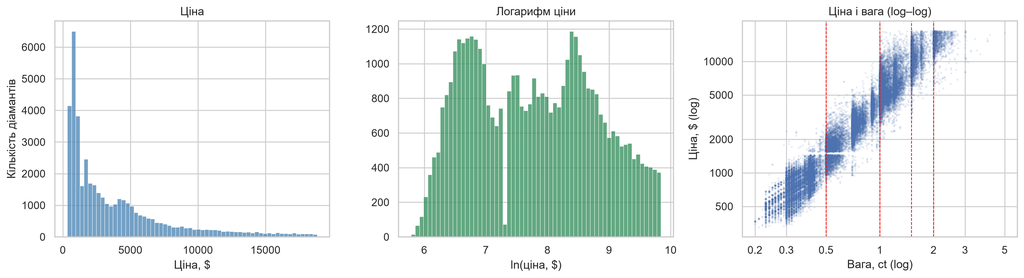

Рисунок 1: EDA на навчальній частині. Ліворуч: ціна має сильну праву асиметрію, після логарифма розподіл майже симетричний (кілька піків — популярні ваги каменів). Праворуч: у шкалі log–log ціна майже лінійно залежить від ваги, але видно вертикальні «сходинки» на 0.5, 1, 1.5 і 2 ct.

```python
fig, ax = plt.subplots(1, 3, figsize=(15, 4.2))

sns.histplot(train["price"], bins=60, ax=ax[0], color="steelblue")
ax[0].set_title("Ціна")
ax[0].set_xlabel("Ціна, $")
ax[0].set_ylabel("Кількість діамантів")

sns.histplot(train["log_price"], bins=60, ax=ax[1], color="seagreen")
ax[1].set_title("Логарифм ціни")
ax[1].set_xlabel("ln(ціна, $)")
ax[1].set_ylabel("")

ax[2].scatter(train["carat"], train["price"], s=2, alpha=0.08)
ax[2].set_xscale("log")
ax[2].set_yscale("log")
ax[2].axvline(0.5, color="red", lw=0.8, ls="--")
ax[2].axvline(1, color="red", lw=0.8, ls="--")
ax[2].axvline(1.5, color="red", lw=0.8, ls="--")
ax[2].axvline(2, color="red", lw=0.8, ls="--")
ax[2].minorticks_off()
ax[2].set_xticks([0.2, 0.3, 0.5, 1, 2, 3, 5], ["0.2", "0.3", "0.5", "1", "2", "3", "5"])
ax[2].set_yticks([500, 1000, 2000, 5000, 10000], ["500", "1000", "2000", "5000", "10000"])
ax[2].set_title("Ціна і вага (log–log)")
ax[2].set_xlabel("Вага, ct (log)")
ax[2].set_ylabel("Ціна, $ (log)")

plt.tight_layout()
plt.savefig("figures/01_eda_target.png", dpi=150, bbox_inches="tight")
plt.show()

numbers["skew_price"] = round(float(train["price"].skew()), 2)
numbers["skew_log"] = round(float(train["log_price"].skew()), 2)
```

**Код**

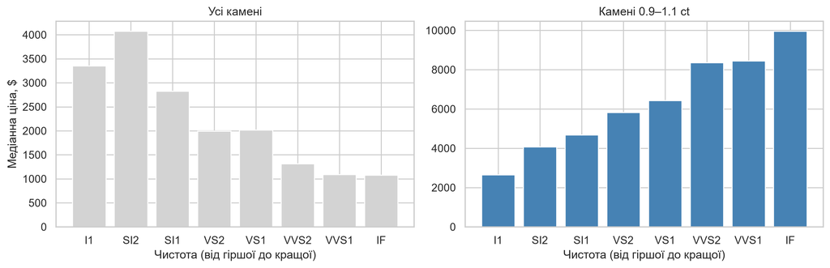

Рисунок 2: Медіанна ціна за чистотою: без контролю ваги (ліворуч) найчистіші камені здаються дешевшими; серед каменів 0.9–1.1 ct (праворуч) ціна чітко зростає з чистотою. Отже, ефекти якості треба оцінювати за сталої ваги.

```python
median_all = train.groupby("clarity", observed=True)["price"].median()

one_carat = train[(train["carat"] >= 0.9) & (train["carat"] <= 1.1)]
median_one_carat = one_carat.groupby("clarity", observed=True)["price"].median()

fig, ax = plt.subplots(1, 2, figsize=(12, 4))

ax[0].bar(median_all.index.astype(str), median_all.values, color="lightgray")
ax[0].set_title("Усі камені")
ax[0].set_xlabel("Чистота (від гіршої до кращої)")
ax[0].set_ylabel("Медіанна ціна, $")

ax[1].bar(median_one_carat.index.astype(str), median_one_carat.values, color="steelblue")
ax[1].set_title("Камені 0.9–1.1 ct")
ax[1].set_xlabel("Чистота (від гіршої до кращої)")

plt.tight_layout()
plt.savefig("figures/02_eda_clarity.png", dpi=150, bbox_inches="tight")
plt.show()
```

Найважливіші висновки з лабораторної №2, перевірені тут на навчальній частині:

- **Розподіл цілі:** асиметрія ціни 1.61, логарифма ціни 0.11. *Рішення:* модель для $\ln(price)$; ефекти тоді у відсотках, а розкид залишків рівніший.
- **Пропуски:** немає. **Викиди:** дорогі й великі камені реальні, їх не видаляю; помилкові рядки вже вилучено на очищенні.
- **Зв’язки й нелінійність:** зв’язок ціни з вагою степеневий (у log–log майже пряма) зі «сходинками» на круглих вагах. *Рішення:* $\ln(carat)$ у базовій лінійній моделі; сплайн і пороги в модифікації.
- **Змішування:** «краща» якість частіше в дрібних каменях (рис. 2). *Рішення:* завжди тримаю вагу в моделі, коли інтерпретую огранку, колір і чистоту.
- **Дублювання:** x, y, z майже ідеально корелюють з вагою (r ≈ 0.98), тому не входять у модель.

## 2.4 Метрики й правило вибору (зафіксовано до відкриття тесту)

- **Основна метрика — MAE**, у доларах: «на скільки в середньому помиляється оцінка ціни». Розподіл ціни дуже асиметричний, і RMSE домінували б кілька найдорожчих каменів. RMSE і $R^2$ подаю як додаткові.
- **Правило вибору:** модель з найменшим середнім MAE на 5 розбиттях. Якщо простіша модель гірша менше ніж на одне стандартне відхилення MAE за розбиттями, беру простішу.
- На тесті один раз оцінюю обрану модель і константний орієнтир. Найкращу **лінійну** модель (вона потрібна для інтерпретації гіпотез) теж один раз оцінюю на тесті, це рішення прийняте заздалегідь.
- Для моделей на $\ln(price)$ прогноз у доларах — $e^{\hat y}$, тобто оцінка **медіани** ціни. Вона узгоджується з MAE, але трохи занижує середню ціну (Duan 1983).

# 3 Результати

**Формули всіх моделей**

```python
formula_m1 = "price ~ carat + C(cut) + C(color) + C(clarity)"

formula_m2 = "log_price ~ log_carat + C(cut) + C(color) + C(clarity)"

formula_m3 = ("log_price ~ bs(log_carat, df=6, lower_bound=-2.5, upper_bound=2)"
              " + I(carat >= 0.5) + I(carat >= 1) + I(carat >= 1.5) + I(carat >= 2)"
              " + C(cut) + C(color) + C(clarity)")

formula_m4 = ("log_price ~ bs(log_carat, df=6, lower_bound=-2.5, upper_bound=2)"
              " + I(carat >= 0.5) + I(carat >= 1) + I(carat >= 1.5) + I(carat >= 2)"
              " + C(cut) + C(color) * C(clarity)")

boost_columns = ["carat", "cut_code", "color_code", "clarity_code"]

model_names = {
    "M0": "M0 константа (середнє)",
    "M1": "M1 лінійна, ціна в $",
    "M2": "M2 лінійна log–log",
    "M3": "M3 log–log + сплайн і пороги ваги",
    "M4": "M4 = M3 + взаємодія колір×чистота",
    "M5": "M5 градієнтний бустинг (додатково)",
}
```

## 3.1 Орієнтир: константний прогноз

M0 завжди прогнозує середню ціну навчальної частини, 3 938 $. Це точність «без жодних предикторів»: будь-яка корисна модель має бути помітно кращою (результати в табл. 2).

## 3.2 Базова регресія

Спершу найпростіша лінійна модель у доларах (M1): $price = \beta_0 + \beta_1\,carat + \text{cut} + \text{color} + \text{clarity} + \varepsilon$.

**Код**

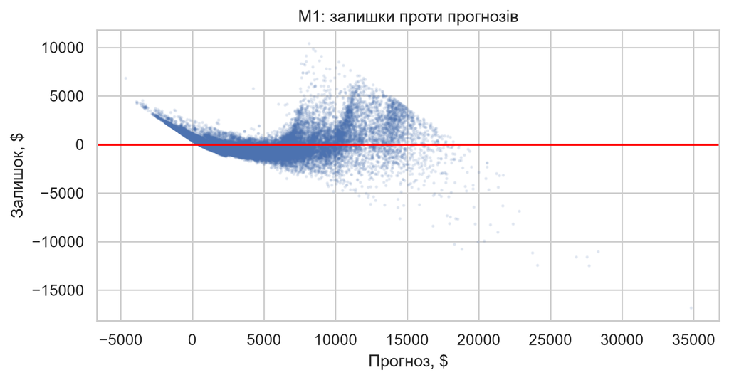

Рисунок 3: M1 (ціна в $): залишки проти прогнозів. Видно дугу (нелінійність), «лійку» (розкид зростає з ціною) і від’ємні прогнози для дрібних каменів.

```python
m1 = smf.ols(formula_m1, data=train).fit()

plt.figure(figsize=(7.5, 4))
plt.scatter(m1.fittedvalues, m1.resid, s=2, alpha=0.1)
plt.axhline(0, color="red")
plt.title("M1: залишки проти прогнозів")
plt.xlabel("Прогноз, $")
plt.ylabel("Залишок, $")
plt.tight_layout()
plt.savefig("figures/03_m1_residuals.png", dpi=150, bbox_inches="tight")
plt.show()

numbers["m1_neg"] = int((m1.fittedvalues < 0).sum())
```

M1 має три вади: 4061 каменів отримують **від’ємну** ціну, залишки утворюють дугу (зв’язок не лінійний), а розкид росте з ціною. Тому як **базову регресію для висновків** беру лог-лінійну модель, яку підказали EDA й література (M2):

$$\ln(price) = \beta_0 + \beta_1 \ln(carat) + \sum \gamma_{cut} + \sum \delta_{color} + \sum \theta_{clarity} + \varepsilon$$

Еталонні рівні: огранка Fair, колір J, чистота I1. Коефіцієнти я оцінив на всій навчальній частині OLS зі стійкими до гетероскедастичності похибками HC3.

**Код**

```python
m2 = smf.ols(formula_m2, data=train).fit(cov_type="HC3")
ci = m2.conf_int()

coef = pd.DataFrame()
coef["β"] = m2.params
coef["ДІ 2.5 %"] = ci[0]
coef["ДІ 97.5 %"] = ci[1]
coef["надбавка, %"] = (np.exp(m2.params) - 1) * 100
coef.loc["Intercept", "надбавка, %"] = np.nan
coef.loc["log_carat", "надбавка, %"] = np.nan
coef = coef.round(3)
coef = coef.fillna("—")
coef.to_csv("results/m2_coefficients.csv")

b1 = float(m2.params["log_carat"])
clarity_beta = m2.params[["C(clarity)[T.SI2]", "C(clarity)[T.SI1]", "C(clarity)[T.VS2]",
                          "C(clarity)[T.VS1]", "C(clarity)[T.VVS2]", "C(clarity)[T.VVS1]",
                          "C(clarity)[T.IF]"]]

numbers["b1"] = round(b1, 3)
numbers["b1_lo"] = round(float(ci.loc["log_carat", 0]), 3)
numbers["b1_hi"] = round(float(ci.loc["log_carat", 1]), 3)
numbers["r2_m2"] = round(float(m2.rsquared), 4)
numbers["si2_prem"] = round(float(np.exp(m2.params["C(clarity)[T.SI2]"]) - 1) * 100)
numbers["if_prem"] = round(float(np.exp(m2.params["C(clarity)[T.IF]"]) - 1) * 100)
numbers["if_lo"] = round(float(np.exp(ci.loc["C(clarity)[T.IF]", 0]) - 1) * 100)
numbers["if_hi"] = round(float(np.exp(ci.loc["C(clarity)[T.IF]", 1]) - 1) * 100)
numbers["clar_monotone"] = bool(clarity_beta.is_monotonic_increasing and (clarity_beta > 0).all())
numbers["d_prem"] = round(float(np.exp(m2.params["C(color)[T.D]"]) - 1) * 100)
numbers["ideal_prem"] = round(float(np.exp(m2.params["C(cut)[T.Ideal]"]) - 1) * 100)

coef
```

Таблиця 1: M2: ключові коефіцієнти, 95 % ДІ (HC3) і надбавка до ціни за сталих інших змінних

|  | β | ДІ 2.5 % | ДІ 97.5 % | надбавка, % |
| --- | --- | --- | --- | --- |
| Intercept | 7.343 | 7.321 | 7.365 | — |
| C(cut)[T.Good] | 0.086 | 0.075 | 0.096 | 8.94 |
| C(cut)[T.Very Good] | 0.122 | 0.112 | 0.132 | 13.0 |
| C(cut)[T.Premium] | 0.144 | 0.134 | 0.154 | 15.474 |
| C(cut)[T.Ideal] | 0.166 | 0.156 | 0.176 | 18.036 |
| C(color)[T.I] | 0.138 | 0.131 | 0.145 | 14.763 |
| C(color)[T.H] | 0.260 | 0.253 | 0.267 | 29.699 |
| C(color)[T.G] | 0.350 | 0.343 | 0.356 | 41.874 |
| C(color)[T.F] | 0.415 | 0.408 | 0.422 | 51.432 |
| C(color)[T.E] | 0.455 | 0.448 | 0.462 | 57.62 |
| C(color)[T.D] | 0.511 | 0.503 | 0.518 | 66.626 |
| C(clarity)[T.SI2] | 0.427 | 0.407 | 0.446 | 53.24 |
| C(clarity)[T.SI1] | 0.592 | 0.572 | 0.611 | 80.672 |
| C(clarity)[T.VS2] | 0.742 | 0.723 | 0.761 | 110.005 |
| C(clarity)[T.VS1] | 0.811 | 0.791 | 0.830 | 124.972 |
| C(clarity)[T.VVS2] | 0.946 | 0.926 | 0.966 | 157.497 |
| C(clarity)[T.VVS1] | 1.018 | 0.998 | 1.038 | 176.801 |
| C(clarity)[T.IF] | 1.112 | 1.091 | 1.133 | 204.128 |
| log_carat | 1.884 | 1.881 | 1.887 | — |

**Інтерпретація в одиницях задачі** ($R^2$ на шкалі логарифма = 0.9828):

- **Вага:** $\hat\beta_1 =$ 1.884 (95 % ДІ 1.881–1.887). Камінь на 1 % важчий коштує в середньому на ≈ 1.88 % дорожче. Камінь, удвічі важчий за ту саму якість, коштує в $2^{\hat\beta_1} \approx$ 3.7 раза більше.
- **Чистота:** порівняно з I1 надбавка зростає від 53 % (SI2) до 204 % (IF, 95 % ДІ 198–211 %).
- **Колір:** найкращий колір D дорожчий за J на ≈ 67 %.
- **Огранка:** Ideal дорожча за Fair лише на ≈ 18 %. Огранка важить найменше з 4C.

### 3.2.1 Діагностика залишків M2

**Код**

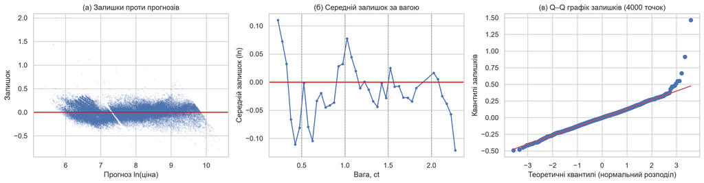

Рисунок 4: Діагностика M2. (а) Залишки проти прогнозів: дуги й лійки M1 майже немає. (б) Середній залишок за вагою: систематична хвиля від −0.12 до +0.11 зі зламами біля 0.5, 1, 1.5 і 2 ct. (в) Q–Q графік: правий хвіст важчий за нормальний.

```python
fig, ax = plt.subplots(1, 3, figsize=(16, 4.3))

ax[0].scatter(m2.fittedvalues, m2.resid, s=2, alpha=0.08)
ax[0].axhline(0, color="red")
ax[0].set_title("(а) Залишки проти прогнозів")
ax[0].set_xlabel("Прогноз ln(ціна)")
ax[0].set_ylabel("Залишок")

bins = np.arange(0.2, 2.31, 0.05)
train_resid = train.copy()
train_resid["resid"] = m2.resid
train_resid["weight_bin"] = pd.cut(train_resid["carat"], bins)
resid_by_weight = train_resid.groupby("weight_bin", observed=True)["resid"].agg(["mean", "size"])
resid_by_weight = resid_by_weight[resid_by_weight["size"] >= 30]
bin_middle = []
for interval in resid_by_weight.index:
    bin_middle.append(interval.mid)

ax[1].plot(bin_middle, resid_by_weight["mean"], marker="o", ms=3)
ax[1].axhline(0, color="red")
ax[1].axvline(0.5, color="gray", ls="--", lw=0.8)
ax[1].axvline(1, color="gray", ls="--", lw=0.8)
ax[1].axvline(1.5, color="gray", ls="--", lw=0.8)
ax[1].axvline(2, color="gray", ls="--", lw=0.8)
ax[1].set_title("(б) Середній залишок за вагою")
ax[1].set_xlabel("Вага, ct")
ax[1].set_ylabel("Середній залишок (ln)")

stats.probplot(m2.resid.sample(4000, random_state=42), dist="norm", plot=ax[2])
ax[2].set_title("(в) Q–Q графік залишків (4000 точок)")
ax[2].set_xlabel("Теоретичні квантилі (нормальний розподіл)")
ax[2].set_ylabel("Квантилі залишків")

plt.tight_layout()
plt.savefig("figures/04_m2_diagnostics.png", dpi=150, bbox_inches="tight")
plt.show()
```

**Код**

```python
m2_simple = smf.ols(formula_m2, data=train).fit()

bp_m1 = het_breuschpagan(m1.resid, m1.model.exog)[1]
bp_m2 = het_breuschpagan(m2_simple.resid, m2_simple.model.exog)[1]

cook = OLSInfluence(m2_simple).cooks_distance[0]
n_cook = int((cook > 4 / len(train)).sum())

n_top = int(0.01 * len(train))
top_rows = np.argsort(cook)[-n_top:]
train_without_top = train.drop(train.index[top_rows])
m2_without_top = smf.ols(formula_m2, data=train_without_top).fit()

spread_expensive = m1.resid[m1.fittedvalues > 10000].std()
spread_cheap = m1.resid[m1.fittedvalues < 2000].std()

numbers["n_cook"] = n_cook
numbers["cook_max"] = round(float(cook.max()), 4)
numbers["b1_wo"] = round(float(m2_without_top.params["log_carat"]), 3)
numbers["sd_ratio"] = round(float(spread_expensive / spread_cheap), 1)

print("Breusch–Pagan, p (M1):", f"{bp_m1:.1e}")
print("Breusch–Pagan, p (M2):", f"{bp_m2:.1e}")
print("Точок з D Кука > 4/n:", n_cook)
print("Максимальна D Кука:", numbers["cook_max"])
print("β ln(carat) без 1 % найвпливовіших точок:", numbers["b1_wo"])
```

```
Breusch–Pagan, p (M1): 0.0e+00
Breusch–Pagan, p (M2): 1.3e-221
Точок з D Кука > 4/n: 2204
Максимальна D Кука: 0.027
β ln(carat) без 1 % найвпливовіших точок: 1.889
```

**Що показала діагностика і що з цього випливає:**

- **Нелінійність.** Логарифми прибрали велику дугу M1, але лишилась систематична «хвиля» за вагою (рис. 4 б). Камені 0.4–0.5 ct і 0.55–0.85 ct модель переоцінює (середній залишок до −0.12, тобто прогноз на ≈ 11 % завищений), а камені близько 1 ct і найдрібніші недооцінює (до +0.11). Злами кривої припадають на 0.5, 1, 1.5 і 2 ct, тобто на «круглі» ваги (Scott і Yelowitz 2010). *Наслідок для прогнозу:* систематична похибка до ≈ 10 % для цілих груп каменів. *Наслідок для коефіцієнтів:* $\beta_1$ є усередненою еластичністю, а не сталою для всіх ваг.
- **Неоднаковий розкид.** У M1 розкид залишків для дорогих каменів у 3.2 раза більший, ніж для дешевих. У M2 він значно рівніший, проте тест Бройша–Пагана все одно відхиляє гомоскедастичність (при n ≈ 43 000 він чутливий навіть до малих відхилень). Тому для ДІ я використав **HC3**. Q–Q графік показує важкі хвости, тож прогнозні інтервали на основі нормальності були б завузькими.
- **Впливові спостереження.** 2204 точок мають D Кука > 4/n, але максимум лише 0.027 (далеко від 1). Без 1 % найвпливовіших точок $\hat\beta_1$ = 1.889 замість 1.884. Висновки від них не залежать.

## 3.3 Спроба покращення

**Проблема:** хвиля в залишках за вагою (рис. 4 б). **Модифікації:**

- **M3** замінює пряму $\ln(carat)$ на кубічний сплайн від $\ln(carat)$ (6 ступенів свободи, вузли за навчальною частиною) і додає 4 порогові змінні $[carat \ge 0.5], [\ge 1], [\ge 1.5], [\ge 2]$ з роботи Scott і Yelowitz.
- **M4** додатково дозволяє надбавці за колір залежати від чистоти (взаємодія color × clarity). У лабораторній №2 теплова карта медіанних цін «колір × чистота» для каменів 1 ct показала, що ці надбавки не просто додаються одна до одної.

Ridge не розглядаю: предикторів лише ~20 на ~43 000 спостережень, мультиколінеарності між 4C немає, тож штраф майже не змінить коефіцієнтів.

## 3.4 Додаткова модель

**M5** — градієнтний бустинг (`HistGradientBoostingRegressor`, параметри за замовчуванням) на тих самих 4 предикторах і тій самій цілі $\ln(price)$. Він сам знаходить пороги й взаємодії, але не має коефіцієнтів для інтерпретації.

## 3.5 Порівняння за перехресною валідацією

**Код**

```python
kfold = KFold(n_splits=5, shuffle=True, random_state=42)

mae = {"M0": [], "M1": [], "M2": [], "M3": [], "M4": [], "M5": []}
rmse = {"M0": [], "M1": [], "M2": [], "M3": [], "M4": [], "M5": []}
r2 = {"M0": [], "M1": [], "M2": [], "M3": [], "M4": [], "M5": []}

for train_index, valid_index in kfold.split(train):
    part_train = train.iloc[train_index]
    part_valid = train.iloc[valid_index]
    predictions = {}

    predictions["M0"] = np.full(len(part_valid), part_train["price"].mean())

    model = smf.ols(formula_m1, data=part_train).fit()
    predictions["M1"] = model.predict(part_valid)

    model = smf.ols(formula_m2, data=part_train).fit()
    predictions["M2"] = np.exp(model.predict(part_valid))

    model = smf.ols(formula_m3, data=part_train).fit()
    predictions["M3"] = np.exp(model.predict(part_valid))

    model = smf.ols(formula_m4, data=part_train).fit()
    predictions["M4"] = np.exp(model.predict(part_valid))

    booster = HistGradientBoostingRegressor(random_state=42)
    booster.fit(part_train[boost_columns], part_train["log_price"])
    predictions["M5"] = np.exp(booster.predict(part_valid[boost_columns]))

    for name in predictions:
        mae[name].append(mean_absolute_error(part_valid["price"], predictions[name]))
        rmse[name].append(root_mean_squared_error(part_valid["price"], predictions[name]))
        r2[name].append(r2_score(part_valid["price"], predictions[name]))

rows = []
for name in model_names:
    rows.append({
        "код": name,
        "модель": model_names[name],
        "MAE, $": np.mean(mae[name]),
        "± MAE": np.std(mae[name]),
        "RMSE, $": np.mean(rmse[name]),
        "± RMSE": np.std(rmse[name]),
        "R²": np.mean(r2[name]),
    })

cv_table = pd.DataFrame(rows).set_index("код")

cv_rounded = cv_table.copy()
cv_rounded["MAE, $"] = cv_rounded["MAE, $"].round().astype(int)
cv_rounded["± MAE"] = cv_rounded["± MAE"].round().astype(int)
cv_rounded["RMSE, $"] = cv_rounded["RMSE, $"].round().astype(int)
cv_rounded["± RMSE"] = cv_rounded["± RMSE"].round().astype(int)
cv_rounded["R²"] = cv_rounded["R²"].round(3)
cv_rounded.to_csv("results/cv_comparison.csv", index=False)
cv_rounded
```

Таблиця 2: 5-кратна перехресна валідація на навчальній частині (однакові розбиття). Метрики в доларах; середнє ± стандартне відхилення за 5 розбиттями.

| код | модель | MAE, $ | ± MAE | RMSE, $ | ± RMSE | R² |
| --- | --- | --- | --- | --- | --- | --- |
| M0 | M0 константа (середнє) | 3041 | 23 | 3996 | 42 | -0.000 |
| M1 | M1 лінійна, ціна в $ | 804 | 5 | 1158 | 18 | 0.916 |
| M2 | M2 лінійна log–log | 404 | 6 | 802 | 27 | 0.960 |
| M3 | M3 log–log + сплайн і пороги ваги | 370 | 5 | 706 | 9 | 0.969 |
| M4 | M4 = M3 + взаємодія колір×чистота | 340 | 3 | 638 | 4 | 0.975 |
| M5 | M5 градієнтний бустинг (додатково) | 289 | 2 | 560 | 9 | 0.980 |

**Код**

```python
cv_sorted = cv_table.sort_values("MAE, $")
best = cv_sorted.index[0]
second = cv_sorted.index[1]
difference = cv_table.loc[second, "MAE, $"] - cv_table.loc[best, "MAE, $"]

if second < best and difference < cv_table.loc[best, "± MAE"]:
    chosen = second
else:
    chosen = best

linear_models = cv_table.loc[["M1", "M2", "M3", "M4"]]
best_linear = linear_models["MAE, $"].idxmin()

numbers["chosen"] = model_names[chosen]
numbers["best_linear"] = model_names[best_linear]
numbers["gain_m3"] = round(float(1 - cv_table.loc["M3", "MAE, $"] / cv_table.loc["M2", "MAE, $"]) * 100, 1)
numbers["gain_m4"] = round(float(1 - cv_table.loc["M4", "MAE, $"] / cv_table.loc["M3", "MAE, $"]) * 100, 1)
numbers["gain_gb"] = round(float(1 - cv_table.loc["M5", "MAE, $"] / cv_table.loc[best_linear, "MAE, $"]) * 100, 1)

print("Обрана модель (до відкриття тесту):", model_names[chosen])
print("Найкраща лінійна модель:", model_names[best_linear])
```

```
Обрана модель (до відкриття тесту): M5 градієнтний бустинг (додатково)
Найкраща лінійна модель: M4 = M3 + взаємодія колір×чистота
```

**Що показала валідація:**

- Усі регресії значно кращі за орієнтир M0. Перехід до логарифмів (M1 → M2) зменшує MAE приблизно вдвічі. Отже, форма зв’язку важить більше за вибір предикторів.
- **Сплайн і пороги (M3)** зменшують MAE ще на 8.4 % порівняно з M2, різниця набагато більша за розкид між розбиттями. Модифікація розв’язала проблему, яку показала діагностика.
- **Взаємодія колір × чистота (M4)** зменшує MAE ще на 8.1 % порівняно з M3.
- **Бустинг (M5)** точніший за найкращу лінійну модель на 15.0 %, але не має коефіцієнтів. Тому гіпотези перевіряю в M2, а для прогнозу беру модель за правилом вибору.

## 3.6 Фінальна оцінка на тесті

**Код**

```python
pred_m0 = np.full(len(test), train["price"].mean())

final_booster = HistGradientBoostingRegressor(random_state=42)
final_booster.fit(train[boost_columns], train["log_price"])
pred_m5 = np.exp(final_booster.predict(test[boost_columns]))

final_m4 = smf.ols(formula_m4, data=train).fit()
pred_m4 = np.exp(final_m4.predict(test))

test_rows = []
for name, prediction in [("M0", pred_m0), ("M5", pred_m5), ("M4", pred_m4)]:
    relative_error = abs(test["price"] - prediction) / test["price"] * 100
    test_rows.append({
        "модель": model_names[name],
        "MAE, $": round(float(mean_absolute_error(test["price"], prediction))),
        "RMSE, $": round(float(root_mean_squared_error(test["price"], prediction))),
        "R²": round(float(r2_score(test["price"], prediction)), 3),
        "медіана |помилки| / ціна, %": round(float(np.median(relative_error)), 1),
    })

test_table = pd.DataFrame(test_rows)
test_table.to_csv("results/test_metrics.csv", index=False)
numbers["test"] = test_rows
test_table
```

Таблиця 3: Одноразова оцінка на тестовій частині. Моделі перенавчено на всій навчальній частині.

|  | модель | MAE, $ | RMSE, $ | R² | медіана \|помилки\| / ціна, % |
| --- | --- | --- | --- | --- | --- |
| 0 | M0 константа (середнє) | 2990 | 3940 | -0.000 | 74.6 |
| 1 | M5 градієнтний бустинг (додатково) | 289 | 558 | 0.980 | 6.2 |
| 2 | M4 = M3 + взаємодія колір×чистота | 341 | 637 | 0.974 | 7.4 |

**Код**

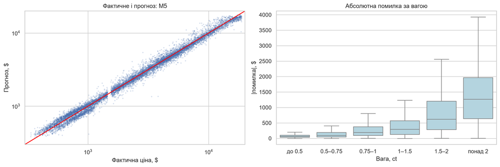

Рисунок 5: Тест: фактична ціна проти прогнозу обраної моделі (log-шкали; червона лінія — ідеальний прогноз) і абсолютна помилка за групами ваги.

```python
err = test.copy()
err["pred"] = pred_m5
err["abs_err"] = abs(err["price"] - err["pred"])
err["rel_err"] = err["abs_err"] / err["price"] * 100
err["група ваги"] = pd.cut(err["carat"], [0, 0.5, 0.75, 1, 1.5, 2, 5.1],
                           labels=["до 0.5", "0.5–0.75", "0.75–1", "1–1.5", "1.5–2", "понад 2"])

fig, ax = plt.subplots(1, 2, figsize=(14, 4.8))

ax[0].scatter(err["price"], err["pred"], s=3, alpha=0.15)
ax[0].plot([300, 20000], [300, 20000], color="red")
ax[0].set_xscale("log")
ax[0].set_yscale("log")
ax[0].set_xlim(300, 20000)
ax[0].set_ylim(300, 20000)
ax[0].set_title("Фактичне і прогноз: M5")
ax[0].set_xlabel("Фактична ціна, $")
ax[0].set_ylabel("Прогноз, $")

sns.boxplot(data=err, x="група ваги", y="abs_err", ax=ax[1], showfliers=False, color="lightblue")
ax[1].set_title("Абсолютна помилка за вагою")
ax[1].set_xlabel("Вага, ct")
ax[1].set_ylabel("|помилка|, $")

plt.tight_layout()
plt.savefig("figures/05_test_pred.png", dpi=150, bbox_inches="tight")
plt.show()
```

**Код**

```python
by_weight = err.groupby("група ваги", observed=True).agg(
    n=("price", "size"),
    median_price=("price", "median"),
    MAE=("abs_err", "mean"),
    median_rel_err=("rel_err", "median"),
)
by_weight = by_weight.round(1)
by_weight.to_csv("results/test_errors_by_carat.csv")

numbers["rel_err_small"] = float(by_weight["median_rel_err"].iloc[0])
numbers["rel_err_large"] = float(by_weight["median_rel_err"].iloc[-1])

by_weight.columns = ["каменів", "медіана ціни, $", "MAE, $", "медіана відн. помилки, %"]
by_weight
```

Таблиця 4: Помилки обраної моделі на тесті за групами ваги.

| група ваги | каменів | медіана ціни, $ | MAE, $ | медіана відн. помилки, % |
| --- | --- | --- | --- | --- |
| до 0.5 | 3726 | 789.0 | 75.6 | 8.7 |
| 0.5–0.75 | 2296 | 2072.0 | 149.2 | 4.8 |
| 0.75–1 | 1261 | 3774.0 | 276.3 | 5.2 |
| 1–1.5 | 2431 | 5832.0 | 419.2 | 4.8 |
| 1.5–2 | 661 | 10889.0 | 863.7 | 5.5 |
| понад 2 | 375 | 15371.0 | 1438.4 | 8.2 |

**Код**

```python
expensive = err[err["price"] > 15000]
big_stones = err[err["carat"] >= 1.5]

numbers["n_cap"] = len(expensive)
numbers["mae_cap"] = round(float(expensive["abs_err"].mean()))
numbers["share_big_n"] = round(len(big_stones) / len(err) * 100)
numbers["share_big_err"] = round(float(big_stones["abs_err"].sum() / err["abs_err"].sum()) * 100)

worst = err.sort_values("abs_err", ascending=False).head(6)
worst = worst[["carat", "cut", "color", "clarity", "price", "pred", "abs_err"]]
worst["pred"] = worst["pred"].round().astype(int)
worst["abs_err"] = worst["abs_err"].round().astype(int)
worst.columns = ["вага, ct", "огранка", "колір", "чистота", "ціна, $", "прогноз, $", "|помилка|, $"]
worst
```

Таблиця 5: Шість каменів тесту з найбільшою помилкою обраної моделі.

|  | вага, ct | огранка | колір | чистота | ціна, $ | прогноз, $ | \|помилка\|, $ |
| --- | --- | --- | --- | --- | --- | --- | --- |
| 27531 | 4.50 | Fair | J | I1 | 18531 | 10411 | 8120 |
| 19833 | 2.25 | Very Good | J | SI2 | 8442 | 13623 | 5181 |
| 26444 | 3.67 | Premium | I | I1 | 16193 | 11131 | 5062 |
| 20265 | 1.50 | Very Good | F | VS2 | 8736 | 13620 | 4884 |
| 21905 | 1.83 | Premium | I | VS2 | 10043 | 14846 | 4803 |
| 16228 | 3.00 | Very Good | H | I1 | 6512 | 11026 | 4514 |

**Де помилки найбільші.** У доларах помилка росте з вагою й ціною: камені від 1.5 ct становлять 11 % тесту, але дають 39 % сумарної абсолютної помилки. У відсотках картина інша: медіанна відносна помилка ≈ 5 % для каменів 0.5–2 ct, але 8.7 % для дрібних (до 0.5 ct) і 8.2 % для каменів понад 2 ct. Розрив на графіку біля 1 500 $ походить з даних: у наборі майже немає цін між 1 455 і 1 545 $ (див. лабораторну №2). Найбільші абсолютні помилки — у дорогих каменів поблизу верхньої межі цін набору (325 каменів дорожчих за 15 000 $, MAE 1 244 $): там ціни обрізані, а інші характеристики (флуоресценція, пропорції, сертифікат, продавець) у дані не потрапили.

**Код**

```python
with open("results/key_numbers.json", "w", encoding="utf-8") as f:
    json.dump(numbers, f, ensure_ascii=False, indent=2)
```

# 4 Обговорення й висновки

**Відповідь на дослідницьке питання.** Чотири характеристики з сертифіката прогнозують ціну нового діаманта з того самого ринку дуже добре. Обрана модель на тесті помиляється в середньому на 289 $, тоді як константний прогноз — на 2 990 $. Типова (медіанна) відносна помилка становить 6.2 %. Найкраща лінійна модель трохи гірша (MAE 341 $), зате пояснює, як саме 4C пов’язані з ціною.

**H1 (вага).** Еластичність 1.884, 95 % ДІ 1.881–1.887. Інтервал вузький і цілком лежить вище 1, тож за сталих інших C ціна зростає з вагою швидше, ніж пропорційно. Дані **узгоджуються з H1**. Оцінка більша за нахил 1.68 з лабораторної №2, бо там вага не була «очищена» від якості: великі камені частіше мають гіршу чистоту й колір. Застереження: діагностика показала, що еластичність не стала (стрибки на круглих вагах), а гіпотеза походить з EDA, тож результат розвідувальний.

**H2 (чистота).** Усі 7 коефіцієнтів чистоти додатні, з вузькими ДІ, і зростають від SI2 до IF (монотонно). Надбавка IF над I1 становить 204 % (95 % ДІ 198–211 %), що більше за 100 %. Дані **узгоджуються з H2** (так само розвідувально).

**Якість прогнозу на нових даних.** Різниця між MAE на перехресній валідації й на тесті мала, отже модель не перенавчена. Однак тест не повністю незалежний: рішення про логарифми й набір предикторів я ухвалив після EDA всього набору.

**Межі узагальнення й змішувальні чинники.**

- Дані — один ринок і один рік (2008), лише круглі камені, ціни до 18 823 $. На інші роки, валюти, форми каменів чи синтетичні діаманти результат не переноситься.
- Це **спостережні** дані, тому коефіцієнти описують **асоціації** в каталогах, а не причинний вплив. Змішувальні чинники, яких немає в даних: продавець і його націнка, лабораторія сертифікації (GIA чи інша), флуоресценція, симетрія й полірування, дата пропозиції.
- Ціни взято з каталогу (ціни пропозиції), а не з реальних угод.

**Продовження дослідження.** Зібрати свіжі дані з кількох онлайн-магазинів з датою, продавцем, лабораторією сертифікації й флуоресценцією. Перевірити зафіксовані моделі (M5 для прогнозу, M4 для інтерпретації) на них як на справді незалежному тесті та оцінити, чи збереглися надбавки за «круглі» ваги через 15+ років.

# Бібліографія

Chu, Singfat. 2001. «Pricing the C’s of Diamond Stones». *Journal of Statistics Education* 9 (2). https://jse.amstat.org/v9n2/datasets.chu.html.

Duan, Naihua. 1983. «Smearing Estimate: A Nonparametric Retransformation Method». *Journal of the American Statistical Association* 78 (383): 605–10. https://doi.org/10.1080/01621459.1983.10478017.

James, Gareth, Daniela Witten, Trevor Hastie, Robert Tibshirani, і Jonathan Taylor. 2023. *An Introduction to Statistical Learning with Applications in Python*. Springer. https://doi.org/10.1007/978-3-031-38747-0.

Kuhn, Max, і Julia Silge. 2022. *Tidy Modeling with R*. O’Reilly. https://www.tmwr.org/.

NIST/SEMATECH. 2012. *e-Handbook of Statistical Methods: How can I tell if a model fits my data?* https://www.itl.nist.gov/div898/handbook/pmd/section4/pmd44.htm.

Sandve, Geir Kjetil, Anton Nekrutenko, James Taylor, і Eivind Hovig. 2013. «Ten Simple Rules for Reproducible Computational Research». *PLoS Computational Biology* 9 (10): e1003285. https://doi.org/10.1371/journal.pcbi.1003285.

Scott, Frank, і Aaron Yelowitz. 2010. «Pricing Anomalies in the Market for Diamonds: Evidence of Conformist Behavior». *Economic Inquiry* 48 (2): 353–68. https://doi.org/10.1111/j.1465-7295.2009.00237.x.

Wickham, Hadley. 2016. *ggplot2: Elegant Graphics for Data Analysis*. Springer. https://doi.org/10.1007/978-3-319-24277-4.

Wickham, Hadley, і Garrett Grolemund. 2017. *R for Data Science*. O’Reilly. https://r4ds.had.co.nz/.